# Assignment 1

Ignacio González García-Valdés

## THE INSURANCE COMPANY (TIC) 2000

Este conjunto de datos es propiedad de la empresa holandesa de minería de datos Sentient Machine Research y lo proporciona. Esta información se puede utilizar para clasificar si se condece un seguro de caravanas o no.

#### VARABLE OBJECTIVO

La variable objetivo respecto a este dataset es la siguiente: Attribute 86, "CARAVAN:Number of mobile home policies", is the target variable.

#### Importo librerías

```python
import pandas as pd
import numpy as np
import seaborn as sns
from matplotlib import pyplot as plt
import plotly.express as px
from scipy.stats import chi2_contingency
import warnings

pd.set_option('display.max_columns', 500)
pd.set_option('display.max_rows', 5000)
```

#### Funciones

```python
def cramers_V_rule(var1,var2) :

  crosstab =np.array(pd.crosstab(var1,var2, rownames=None, colnames=None)) # creamos el cruce de tablas
  stat = chi2_contingency(crosstab)[0] # Chi2 test
  obs = np.sum(crosstab) # número de observaciones
  mini = min(crosstab.shape)-1 # Cogemos el valor mínimo
  return (stat/(obs*mini))

def plot_feature_categorical_variables(df, col_name, target):
    """
    Visualize a variable with and without faceting on the loan status.
    - df dataframe
    - col_name is the variable name in the dataframe
    - full_name is the full variable name
    """
    f, (ax1, ax2) = plt.subplots(nrows=1, ncols=2, figsize=(12,3), dpi=90)

    count_null = df[col_name].isnull().sum()

    sns.countplot(df[col_name], order=sorted(df[col_name].unique()), color='#5975A4', saturation=1, ax=ax1)
    ax1.set_xlabel(col_name)
    ax1.set_ylabel('Count')
    ax1.set_title(col_name+ ' Numero de nulos: '+str(count_null))
    plt.xticks(rotation = 90)


    sns.countplot(df[target], order=sorted(df[target].unique()), color='#5975A4', saturation=1, ax=ax2)
    ax2.set_xlabel(target)
    ax2.set_ylabel('Count')
    ax2.set_title(target + ' Numero de nulos: '+str(count_null))
    plt.xticks(rotation = 90)

    plt.tight_layout()

def get_corr_matrix(dataset = None, metodo='pearson', size_figure=[10,8]):
    # Para obtener la correlación de Spearman, sólo cambiar el metodo por 'spearman'

    if dataset is None:
        print(u'\nHace falta pasar argumentos a la función')
        return 1
    sns.set(style="white")
    # Compute the correlation matrix
    corr = dataset.corr(method=metodo)
    # Set self-correlation to zero to avoid distraction
    for i in range(corr.shape[0]):
        corr.iloc[i, i] = 0
    # Set up the matplotlib figure
    f, ax = plt.subplots(figsize=size_figure)
    # Draw the heatmap with the mask and correct aspect ratio
    sns.heatmap(corr, center=0,
                square=True, linewidths=.5,  cmap ='viridis' ) #cbar_kws={"shrink": .5}
    plt.show()

    return 0

def plot_feature_numeric_variables(df, col_name, target):
    """
    Visualize a variable with and without faceting on the loan status.
    - df dataframe
    - col_name is the variable name in the dataframe
    - full_name is the full variable name
    """
    f, (ax1, ax2) = plt.subplots(nrows=1, ncols=2, figsize=(12,3), dpi=90)

    count_null = df[col_name].isnull().sum()

    sns.countplot(df[col_name], order=sorted(df[col_name].unique()), color='#5975A4', saturation=1, ax=ax1)
    ax1.set_xlabel(col_name)
    ax1.set_ylabel('Count')
    ax1.set_title(col_name+ ' Numero de nulos: '+str(count_null))
    plt.xticks(rotation = 90)


    data = df.groupby(col_name)[target].value_counts(normalize=True).to_frame('proportion').reset_index()
    data.columns = [i, target, 'proportion']
    #sns.barplot(x = col_name, y = 'proportion', hue= target, data = data, saturation=1, ax=ax2)
    sns.barplot(x = col_name, y = 'proportion', hue= target, data = data, saturation=1, ax=ax2)
    ax2.set_ylabel(target+' fraction')
    ax2.set_title(target)
    plt.xticks(rotation = 90)
    ax2.set_xlabel(col_name)

    plt.tight_layout()

def get_deviation_of_mean_perc(df, list_var_numeric, target, multiplier):
    """
    Devuelve el porcentaje de valores que exceden del intervalo de confianza
    :type series:
    :param multiplier:
    :return:
    """
    pd_final = pd.DataFrame()

    for i in list_var_numeric:

        series_mean = df[i].mean()
        series_std = df[i].std()
        std_amp = multiplier * series_std
        left = series_mean - std_amp
        right = series_mean + std_amp
        size_s = df[i].size

        perc_goods = df[i][(df[i] >= left) & (df[i] <= right)].size/size_s
        perc_excess = df[i][(df[i] < left) | (df[i] > right)].size/size_s

        if perc_excess>0:
            pd_concat_percent = pd.DataFrame(df[target][(df[i] < left) | (df[i] > right)]\
                                            .value_counts(normalize=True).reset_index()).T
            pd_concat_percent = pd_concat_percent.drop('index',axis=0)
            pd_concat_percent['variable'] = i
            pd_concat_percent['sum_outlier_values'] = df[i][(df[i] < left) | (df[i] > right)].size
            pd_final = pd.concat([pd_final, pd_concat_percent], axis=0).reset_index(drop=True)

    if pd_final.empty:
        print('No existen variables con valores nulos')

    return pd_final
```

#### Warnings

```python
warnings.filterwarnings('ignore')
```

#### CARGA DEL DICCIONARIO

```python
dictionary_data=pd.read_excel('../data/dictionary.xlsx', sheet_name='dictionary')
dictionary_data.head(10)
```

|  | feature | nombre | descripcion | categoria | clave |
| --- | --- | --- | --- | --- | --- |
| 0 | customer_subtype | MOSTYPE | Customer Subtype | categoria | L0 |
| 1 | num_houses_1_10 | MAANTHUI | Number of houses 1 –10 | numero | None |
| 2 | avg_size_household_1_6 | MGEMOMV | Avg size household 1 –6 | numero | None |
| 3 | avg_age | MGEMLEEF | Avg age see L1 | ordinal | L1 |
| 4 | customer_type | MOSHOOFD | Customer main type see L2 | categoria | L2 |
| 5 | roman_catholic | MGODRK | Roman catholic see L3 | ordinal | L3 |
| 6 | protestant | MGODPR | Protestant ... | ordinal | L3 |
| 7 | other_religion | MGODOV | Other religion | ordinal | L3 |
| 8 | no_religion | MGODGE | No religion | ordinal | L3 |
| 9 | married | MRELGE | Married | ordinal | L3 |

```python
dictionary_data.nombre
```

```
0      MOSTYPE
1     MAANTHUI
2      MGEMOMV
3     MGEMLEEF
4     MOSHOOFD
5       MGODRK
6       MGODPR
7       MGODOV
8       MGODGE
9       MRELGE
10      MRELSA
11      MRELOV
12    MFALLEEN
13    MFGEKIND
14    MFWEKIND
```

[output cut: 72 more lines]

Establecemeos la ruta del diccionario. En mi caso, seguimos el project template que se nos presentó. Por lo tanto, los datos se situan en la carpeta data

#### CARGA DE DATOS

```python
train_data = pd.read_csv('../data/ticdata2000.txt',names= dictionary_data.nombre, delimiter='\t')
test_data = pd.read_csv('../data/ticeval2000.txt', names= dictionary_data.nombre, delimiter='\t')
test_target = pd.read_csv('../data/tictgts2000.txt')
```

Cambiamos los nombres de las columnas utilizando names, ya que el datase viene sin los nombres de las variables.

```python
train_data.head()
```

|  | MOSTYPE | MAANTHUI | MGEMOMV | MGEMLEEF | MOSHOOFD | MGODRK | MGODPR | MGODOV | MGODGE | MRELGE | MRELSA | MRELOV | MFALLEEN | MFGEKIND | MFWEKIND | MOPLHOOG | MOPLMIDD | MOPLLAAG | MBERHOOG | MBERZELF | MBERBOER | MBERMIDD | MBERARBG | MBERARBO | MSKA | MSKB1 | MSKB2 | MSKC | MSKD | … |
| --- | --- | --- | --- | --- | --- | --- | --- | --- | --- | --- | --- | --- | --- | --- | --- | --- | --- | --- | --- | --- | --- | --- | --- | --- | --- | --- | --- | --- | --- | --- |
| 0 | 33 | 1 | 3 | 2 | 8 | 0 | 5 | 1 | 3 | 7 | 0 | 2 | 1 | 2 | 6 | 1 | 2 | 7 | 1 | 0 | 1 | 2 | 5 | 2 | 1 | 1 | 2 | 6 | 1 | … |
| 1 | 37 | 1 | 2 | 2 | 8 | 1 | 4 | 1 | 4 | 6 | 2 | 2 | 0 | 4 | 5 | 0 | 5 | 4 | 0 | 0 | 0 | 5 | 0 | 4 | 0 | 2 | 3 | 5 | 0 | … |
| 2 | 37 | 1 | 2 | 2 | 8 | 0 | 4 | 2 | 4 | 3 | 2 | 4 | 4 | 4 | 2 | 0 | 5 | 4 | 0 | 0 | 0 | 7 | 0 | 2 | 0 | 5 | 0 | 4 | 0 | … |
| 3 | 9 | 1 | 3 | 3 | 3 | 2 | 3 | 2 | 4 | 5 | 2 | 2 | 2 | 3 | 4 | 3 | 4 | 2 | 4 | 0 | 0 | 3 | 1 | 2 | 3 | 2 | 1 | 4 | 0 | … |
| 4 | 40 | 1 | 4 | 2 | 10 | 1 | 4 | 1 | 4 | 7 | 1 | 2 | 2 | 4 | 4 | 5 | 4 | 0 | 0 | 5 | 4 | 0 | 0 | 0 | 9 | 0 | 0 | 0 | 0 | … |

Añadimos los nombres de las variables utilizando names al hacer la carga de datos.

```python
test_data.head()
```

|  | MOSTYPE | MAANTHUI | MGEMOMV | MGEMLEEF | MOSHOOFD | MGODRK | MGODPR | MGODOV | MGODGE | MRELGE | MRELSA | MRELOV | MFALLEEN | MFGEKIND | MFWEKIND | MOPLHOOG | MOPLMIDD | MOPLLAAG | MBERHOOG | MBERZELF | MBERBOER | MBERMIDD | MBERARBG | MBERARBO | MSKA | MSKB1 | MSKB2 | MSKC | MSKD | … |
| --- | --- | --- | --- | --- | --- | --- | --- | --- | --- | --- | --- | --- | --- | --- | --- | --- | --- | --- | --- | --- | --- | --- | --- | --- | --- | --- | --- | --- | --- | --- |
| 0 | 33 | 1 | 4 | 2 | 8 | 0 | 6 | 0 | 3 | 5 | 0 | 4 | 1 | 1 | 8 | 2 | 2 | 6 | 0 | 0 | 1 | 2 | 6 | 1 | 0 | 2 | 1 | 5 | 3 | … |
| 1 | 6 | 1 | 3 | 2 | 2 | 0 | 5 | 0 | 4 | 5 | 2 | 2 | 1 | 4 | 5 | 5 | 4 | 0 | 5 | 0 | 0 | 4 | 0 | 0 | 4 | 3 | 0 | 2 | 1 | … |
| 2 | 39 | 1 | 3 | 3 | 9 | 1 | 4 | 2 | 3 | 5 | 2 | 3 | 2 | 3 | 6 | 2 | 4 | 4 | 2 | 1 | 1 | 3 | 2 | 2 | 1 | 1 | 5 | 2 | 1 | … |
| 3 | 9 | 1 | 2 | 3 | 3 | 2 | 3 | 2 | 4 | 5 | 4 | 1 | 2 | 4 | 4 | 2 | 4 | 4 | 2 | 1 | 1 | 5 | 1 | 2 | 3 | 1 | 3 | 2 | 2 | … |
| 4 | 31 | 1 | 2 | 4 | 7 | 0 | 2 | 0 | 7 | 9 | 0 | 0 | 0 | 6 | 3 | 0 | 0 | 9 | 0 | 0 | 0 | 2 | 4 | 4 | 0 | 0 | 0 | 7 | 2 | … |

```python
test_target.head()
```

|  | 0 |
| --- | --- |
| 0 | 1 |
| 1 | 0 |
| 2 | 0 |
| 3 | 0 |
| 4 | 0 |

Podemos observar que faltan los datos de la columna caravan en el df de test. Podemos observar esta discrepancia ya que al importar los datos hemos utilizado los nombres de las variables del diccionario. Al incorporarlas vemos que faltan los datos respecto a esta columna que se encuentran en test_target (si leemos la información facilitada en los documentos podemos ver que efectivamente los datos se encuentran en test target). Por lo tanto, se procede a realizar una unión de las tablas.

```python
test_data['CARAVAN'] = test_target
```

```python
test_data.head()
```

|  | MOSTYPE | MAANTHUI | MGEMOMV | MGEMLEEF | MOSHOOFD | MGODRK | MGODPR | MGODOV | MGODGE | MRELGE | MRELSA | MRELOV | MFALLEEN | MFGEKIND | MFWEKIND | MOPLHOOG | MOPLMIDD | MOPLLAAG | MBERHOOG | MBERZELF | MBERBOER | MBERMIDD | MBERARBG | MBERARBO | MSKA | MSKB1 | MSKB2 | MSKC | MSKD | … |
| --- | --- | --- | --- | --- | --- | --- | --- | --- | --- | --- | --- | --- | --- | --- | --- | --- | --- | --- | --- | --- | --- | --- | --- | --- | --- | --- | --- | --- | --- | --- |
| 0 | 33 | 1 | 4 | 2 | 8 | 0 | 6 | 0 | 3 | 5 | 0 | 4 | 1 | 1 | 8 | 2 | 2 | 6 | 0 | 0 | 1 | 2 | 6 | 1 | 0 | 2 | 1 | 5 | 3 | … |
| 1 | 6 | 1 | 3 | 2 | 2 | 0 | 5 | 0 | 4 | 5 | 2 | 2 | 1 | 4 | 5 | 5 | 4 | 0 | 5 | 0 | 0 | 4 | 0 | 0 | 4 | 3 | 0 | 2 | 1 | … |
| 2 | 39 | 1 | 3 | 3 | 9 | 1 | 4 | 2 | 3 | 5 | 2 | 3 | 2 | 3 | 6 | 2 | 4 | 4 | 2 | 1 | 1 | 3 | 2 | 2 | 1 | 1 | 5 | 2 | 1 | … |
| 3 | 9 | 1 | 2 | 3 | 3 | 2 | 3 | 2 | 4 | 5 | 4 | 1 | 2 | 4 | 4 | 2 | 4 | 4 | 2 | 1 | 1 | 5 | 1 | 2 | 3 | 1 | 3 | 2 | 2 | … |
| 4 | 31 | 1 | 2 | 4 | 7 | 0 | 2 | 0 | 7 | 9 | 0 | 0 | 0 | 6 | 3 | 0 | 0 | 9 | 0 | 0 | 0 | 2 | 4 | 4 | 0 | 0 | 0 | 7 | 2 | … |

Se ha introducido correctamente la columna a los datos de test.

## Exploratory Data Analysis and Preprocessing

El análisis EDA se realizará sobre los datos de entrenamienta, ya que a parte de que los datos de test tienen que permanecer lo más virgenes posibles, el EDA se realizará sobre los datos que se supone que tenemos a priori. En este, caso no podemos conocer lo que contiene test ya que podría interrumpir el buen funcionamiento del modelo. Sin embargo, importamos los datos de test ya que si se realiza algún cambio en las variables tendremos que realizarlo tambien en test.

### Dimensiones del conjunto

```python
train_data.shape
```

```
(5822, 86)
```

### Información de las variables

```python
train_data.info()
```

```
<class 'pandas.core.frame.DataFrame'>
RangeIndex: 5822 entries, 0 to 5821
Data columns (total 86 columns):
 #   Column    Non-Null Count  Dtype
---  ------    --------------  -----
 0   MOSTYPE   5822 non-null   int64
 1   MAANTHUI  5822 non-null   int64
 2   MGEMOMV   5822 non-null   int64
 3   MGEMLEEF  5822 non-null   int64
 4   MOSHOOFD  5822 non-null   int64
 5   MGODRK    5822 non-null   int64
 6   MGODPR    5822 non-null   int64
 7   MGODOV    5822 non-null   int64
 8   MGODGE    5822 non-null   int64
 9   MRELGE    5822 non-null   int64
```

[output cut: 78 more lines]

Es importante saber el tipo de variables con las que estamos trabajando. Tenemos un total de 86 variables de tipo numérico o tipo integer. Esto no significa que las variables sean númericas si no que como podemos observar al imprimir los datos previamente, el dataset contiene números. Sin embargo, al realizar el diccionario gran parte de las variables son categóricas en realidad, teniendo asignadas una serie de categorias a cada número. Por otro lado, podemos observar que no tenemos ninguna variable de tipo string o text. Podría haberlas perfectamente y tener por ejemplo variables "1". No es el caso.

### Observación de valores nulos

```python
sum(train_data.isnull().sum()>0)
```

```
0
```

Como podemos observar el dataset no contiene ningún valor nulo. Asísmo, No existe la necesidad de analizar nulos por columnas y filas. En el caso de existir nulos, si sería necesario ver como se distribuyen los nulos. Por lo tanto, vamos a chequear si hay duplicados.

### Valores duplicados

```python
train_data.duplicated().value_counts()
```

```
False    5220
True      602
dtype: int64
```

Tenemos un total de 602 duplicados. Procedemos a eliminarlos

```python
train_data.drop_duplicates(inplace=True)
train_data.shape
```

```
(5220, 86)
```

### Descripción del dataset

```python
train_data.describe()
```

|  | MOSTYPE | MAANTHUI | MGEMOMV | MGEMLEEF | MOSHOOFD | MGODRK | MGODPR | MGODOV | MGODGE | MRELGE | MRELSA | MRELOV | MFALLEEN | MFGEKIND | MFWEKIND | MOPLHOOG | MOPLMIDD | MOPLLAAG | MBERHOOG | MBERZELF | MBERBOER | MBERMIDD | MBERARBG | MBERARBO | MSKA | MSKB1 | MSKB2 | MSKC | MSKD | … |
| --- | --- | --- | --- | --- | --- | --- | --- | --- | --- | --- | --- | --- | --- | --- | --- | --- | --- | --- | --- | --- | --- | --- | --- | --- | --- | --- | --- | --- | --- | --- |
| count | 5220.000000 | 5220.000000 | 5220.000000 | 5220.000000 | 5220.000000 | 5220.000000 | 5220.000000 | 5220.000000 | 5220.000000 | 5220.000000 | 5220.000000 | 5220.000000 | 5220.000000 | 5220.000000 | 5220.000000 | 5220.000000 | 5220.000000 | 5220.000000 | 5220.000000 | 5220.000000 | 5220.000000 | 5220.000000 | 5220.000000 | 5220.000000 | 5220.000000 | 5220.000000 | 5220.000000 | 5220.000000 | 5220.000000 | … |
| mean | 24.063410 | 1.108429 | 2.669157 | 3.001724 | 5.727969 | 0.710728 | 4.614751 | 1.062452 | 3.263985 | 6.168582 | 0.876628 | 2.315900 | 1.909579 | 3.242912 | 4.267816 | 1.489655 | 3.361494 | 4.537356 | 1.927586 | 0.394828 | 0.525862 | 2.905747 | 2.187548 | 2.304406 | 1.640230 | 1.619732 | 2.201149 | 3.723372 | 1.067241 | … |
| std | 12.939866 | 0.403716 | 0.793202 | 0.818331 | 2.876447 | 1.018999 | 1.721023 | 1.012817 | 1.605713 | 1.917120 | 0.961866 | 1.726682 | 1.817888 | 1.629390 | 2.014015 | 1.634583 | 1.762202 | 2.301799 | 1.802397 | 0.761859 | 1.055965 | 1.848425 | 1.719749 | 1.704299 | 1.718577 | 1.343636 | 1.528850 | 1.927929 | 1.305977 | … |
| min | 1.000000 | 1.000000 | 1.000000 | 1.000000 | 1.000000 | 0.000000 | 0.000000 | 0.000000 | 0.000000 | 0.000000 | 0.000000 | 0.000000 | 0.000000 | 0.000000 | 0.000000 | 0.000000 | 0.000000 | 0.000000 | 0.000000 | 0.000000 | 0.000000 | 0.000000 | 0.000000 | 0.000000 | 0.000000 | 0.000000 | 0.000000 | 0.000000 | 0.000000 | … |
| 25% | 10.000000 | 1.000000 | 2.000000 | 2.000000 | 3.000000 | 0.000000 | 4.000000 | 0.000000 | 2.000000 | 5.000000 | 0.000000 | 1.000000 | 0.000000 | 2.000000 | 3.000000 | 0.000000 | 2.000000 | 3.000000 | 0.000000 | 0.000000 | 0.000000 | 2.000000 | 1.000000 | 1.000000 | 0.000000 | 1.000000 | 1.000000 | 2.000000 | 0.000000 | … |
| 50% | 30.000000 | 1.000000 | 3.000000 | 3.000000 | 7.000000 | 0.000000 | 5.000000 | 1.000000 | 3.000000 | 6.000000 | 1.000000 | 2.000000 | 2.000000 | 3.000000 | 4.000000 | 1.000000 | 3.000000 | 5.000000 | 2.000000 | 0.000000 | 0.000000 | 3.000000 | 2.000000 | 2.000000 | 1.000000 | 2.000000 | 2.000000 | 4.000000 | 1.000000 | … |
| 75% | 35.000000 | 1.000000 | 3.000000 | 3.000000 | 8.000000 | 1.000000 | 6.000000 | 2.000000 | 4.000000 | 7.000000 | 1.000000 | 3.000000 | 3.000000 | 4.000000 | 6.000000 | 2.000000 | 4.000000 | 6.000000 | 3.000000 | 1.000000 | 1.000000 | 4.000000 | 3.000000 | 3.000000 | 2.000000 | 2.000000 | 3.000000 | 5.000000 | 2.000000 | … |
| max | 41.000000 | 10.000000 | 5.000000 | 6.000000 | 10.000000 | 9.000000 | 9.000000 | 5.000000 | 9.000000 | 9.000000 | 7.000000 | 9.000000 | 9.000000 | 9.000000 | 9.000000 | 9.000000 | 9.000000 | 9.000000 | 9.000000 | 5.000000 | 9.000000 | 9.000000 | 9.000000 | 9.000000 | 9.000000 | 9.000000 | 9.000000 | 9.000000 | 9.000000 | … |

Podemos ver cual es el rango de las variables así como la variabilidad de las mismas. Nos hacemos una primera idea de como van a ser la distribución de las diferentes variables

### Exploración de la variable objetivo y tratamiento de la misma

```python
caravan_variable_percentage = train_data['CARAVAN']\
        .value_counts(normalize=True)\
        .mul(100).rename('Percentage').reset_index()

caravan_variable_percentage_count = train_data['CARAVAN'].value_counts().reset_index()
caravan_variable_distribution = pd.merge(caravan_variable_percentage, caravan_variable_percentage_count, on=['index'], how='inner')
caravan_variable_distribution
```

|  | index | Percentage | CARAVAN |
| --- | --- | --- | --- |
| 0 | 0 | 93.48659 | 4880 |
| 1 | 1 | 6.51341 | 340 |

Respecto a la distribución de los datos podemos observar que la mayoría de los datos se situan en la categoría 0.

### Selección de threshold por filas y columnas para eliminar valores missing

Ya hemos verificado previamente si el dataset contenía null values. Por lo tanto no es necesario volver a hacerlo ya que podría llegar a ser redundante.

## Análisis de variables

Teniendo en cuenta la naturaleza de las variables, no podemos ver el grado de correlación de todas las variables del dataset ya que nos encontramos con variables categóricas y numéricas. Por lo tanto, se va a realizar la Cramer´s V correlation matrix para observar el grado de asociación para las variables categóricas y la matriz de correlación de Pearson para las variables numéricas.

### 1. Variables Categóricas

En este caso, el diccionario nos viene muy bien ya que tenemos clasificadas las variables y podemos filtrar por tipo.

Seleccionamos las variables categóricas para poder realizar la matriz correspondiente. Podríamos realizar una función para obtener las variables categóricas como utiliza Ana (función dame_Variables_categóricas). Pero al mantener todas las variables en tipo int esta función no nos servirá.

```python
categorical_column_names = [ 'MOSTYPE','MGEMLEEF','MOSHOOFD', 'MGODRK', 'MGODPR', 'MGODOV','MGODGE', 'MRELGE','MRELSA', 'MRELOV','MFALLEEN',
                            'MFGEKIND','MFWEKIND', 'MOPLHOOG', 'MOPLMIDD', 'MOPLLAAG', 'MBERHOOG','MBERZELF', 'MBERBOER','MBERMIDD', 'MBERARBG',
                            'MBERARBO','MSKA','MSKB1', 'MSKB2', 'MSKC', 'MSKD','MHHUUR', 'MHKOOP', 'MAUT1', 'MAUT2', 'MAUT0', 'MZFONDS', 'MZPART',
                            'MINKM30', 'MINK3045','MINK4575','MINK7512','MINK123M','MINKGEM', 'MKOOPKLA','PWAPART','PWABEDR','PWALAND','PPERSAUT','PBESAUT','PMOTSCO','PVRAAUT',
                            'PAANHANG','PTRACTOR','PWERKT','PBROM','PLEVEN','PPERSONG','PGEZONG','PWAOREG','PBRAND','PZEILPL','PPLEZIER','PFIETS','PINBOED',
                            'PBYSTAND']
```

Excluimos la variable objetivo CARAVAN que tenemos definida como variable categórica.

```python
print(len(categorical_column_names))
```

```
62
```

```python
categorical_variables = train_data[categorical_column_names]
```

Imprimimos para ver que todo este correcto

```python
categorical_variables.head()
```

|  | MOSTYPE | MGEMLEEF | MOSHOOFD | MGODRK | MGODPR | MGODOV | MGODGE | MRELGE | MRELSA | MRELOV | MFALLEEN | MFGEKIND | MFWEKIND | MOPLHOOG | MOPLMIDD | MOPLLAAG | MBERHOOG | MBERZELF | MBERBOER | MBERMIDD | MBERARBG | MBERARBO | MSKA | MSKB1 | MSKB2 | MSKC | MSKD | MHHUUR | MHKOOP | … |
| --- | --- | --- | --- | --- | --- | --- | --- | --- | --- | --- | --- | --- | --- | --- | --- | --- | --- | --- | --- | --- | --- | --- | --- | --- | --- | --- | --- | --- | --- | --- |
| 0 | 33 | 2 | 8 | 0 | 5 | 1 | 3 | 7 | 0 | 2 | 1 | 2 | 6 | 1 | 2 | 7 | 1 | 0 | 1 | 2 | 5 | 2 | 1 | 1 | 2 | 6 | 1 | 1 | 8 | … |
| 1 | 37 | 2 | 8 | 1 | 4 | 1 | 4 | 6 | 2 | 2 | 0 | 4 | 5 | 0 | 5 | 4 | 0 | 0 | 0 | 5 | 0 | 4 | 0 | 2 | 3 | 5 | 0 | 2 | 7 | … |
| 2 | 37 | 2 | 8 | 0 | 4 | 2 | 4 | 3 | 2 | 4 | 4 | 4 | 2 | 0 | 5 | 4 | 0 | 0 | 0 | 7 | 0 | 2 | 0 | 5 | 0 | 4 | 0 | 7 | 2 | … |
| 3 | 9 | 3 | 3 | 2 | 3 | 2 | 4 | 5 | 2 | 2 | 2 | 3 | 4 | 3 | 4 | 2 | 4 | 0 | 0 | 3 | 1 | 2 | 3 | 2 | 1 | 4 | 0 | 5 | 4 | … |
| 4 | 40 | 2 | 10 | 1 | 4 | 1 | 4 | 7 | 1 | 2 | 2 | 4 | 4 | 5 | 4 | 0 | 0 | 5 | 4 | 0 | 0 | 0 | 9 | 0 | 0 | 0 | 0 | 4 | 5 | … |

```python
print(len(categorical_variables.columns))
```

```
62
```

Procedemos a realizar la matriz de confusión y la matriz de Cramer

```python
cramer_matrix = np.zeros((len(categorical_variables.columns),len(categorical_variables.columns)))
categorical_variables_correlated = []

for i in range(0,len(categorical_variables.columns)):
    for j in range(0,len(categorical_variables.columns)):
        cramer_matrix[i,j]=cramers_V_rule(categorical_variables.iloc[:,i],categorical_variables.iloc[:,j])
        if ((cramer_matrix[i,j]>0.8)) :
            if(categorical_variables.columns[i] != categorical_variables.columns[j]):
                categorical_variables_correlated.append((categorical_variables.columns[i],categorical_variables.columns[j]))
```

He decidido incluir una secuencia de if para poder guardar en una nueva variable las variables categóricas que presentan un mayor grado de asociación. Tenemos que tener en cuenta que al comparar una variable con la misma variable, obtendremos un grado de correlación de 1. Tenemos que excluir esta situación al crear la nueva variable. Hacemos esto para poder analizar más en detalle posteriormente las variables con un alto grado de asociación.

```python
print(categorical_variables_correlated)
```

```
[('MOSTYPE', 'MOSHOOFD'), ('MOSTYPE', 'MKOOPKLA'), ('MOSHOOFD', 'MOSTYPE'), ('MHHUUR', 'MHKOOP'), ('MHKOOP', 'MHHUUR'), ('MZFONDS', 'MZPART'), ('MZPART', 'MZFONDS'), ('MKOOPKLA', 'MOSTYPE')]
```

```python
## del categorical_variables_correlated[0]
## print(categorical_variables_correlated)

## del categorical_variables_correlated[2]
## print(categorical_variables_correlated)

## del categorical_variables_correlated[4]
## print(categorical_variables_correlated)

## del categorical_variables_correlated[4]
## print(categorical_variables_correlated)
```

[output not shown]

De esta forma quitamos los duplicados. Hay que tener cuidado de que estamos eliminando correctamente los duplicados ya que el indice se mueve. Seguro que hay una manera más eficiente de realizarlo. Sin embargo, yo no he pododido encontrarla. Por lo tanto, lo que he hecho es realizar el primer delete teniendo el resto entre comillas, luego el dos y asi sucesivamente, teniendo cuidado de cual elimino y que el index del delete corresponde con el valor que se tiene que realizar

```python
categorical_variables_correlated
```

```
[('MOSTYPE', 'MKOOPKLA'),
 ('MOSHOOFD', 'MOSTYPE'),
 ('MHKOOP', 'MHHUUR'),
 ('MZFONDS', 'MZPART')]
```

Imprimimos la matriz.

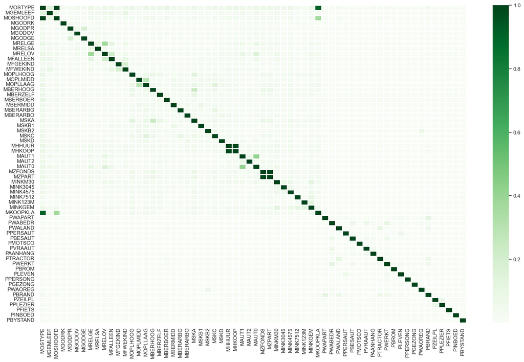

```python
fig, ax = plt.subplots(figsize=(20, 12))
ax.plot()
ax = sns.heatmap(cramer_matrix,cmap="Greens",linewidths=2.0, xticklabels=categorical_variables.columns, yticklabels=categorical_variables.columns)
```

Podemos observar que las variables categóricas por lo general presentan un bajo grado de asociación de acuerdo a la regla de Cramer. Sin embargo, hay algunas variables que si que presentan un grado de asociación con el cual podemos trabajar

#### 1.1. Gráficos de Variables Categóricas

Ahora que ya conocemos los grados de asociación y las variables que presentan un mayor grado, ya estamos en condiciones de crear visualizaciones que realmente nos den una imagen de los datos, sus propiedades y sus relaciones. En este punto, debemos ser sumamente cuidadosos, ya que una mala visualización puede llegar a distorsionar nuestra comprensión, en lugar de ayudarnos.

[figure not shown]

[figure not shown]

[figure not shown]

[figure not shown]

```python
for variable in list(categorical_variables_correlated):
       plot_feature_categorical_variables(train_data, col_name=variable[0], target=variable[1])
```

Podemos observar en estos la distribución de los datos para las diferentes variables categóricas con un alto grado de asociación. En la práctica podríamos decir que los dos últimos pares de variables son simtricas ya que presetan una distribución igual de los datos de forma inversa. De tal forma que lo óptimo sería quitarlas del analisis

### 2. Variables numéricas

Para analizar el grado de asociación entre estas variables realizaremos la correlación de Pearson.

Lo primero que tendremos que hacer por lo tanto, correspondería a la selección de las variables numéricas. Podemos hacerlo manualmente o cogemos las variables categóricas y las excluimos.

```python
numeric_variables = train_data.loc[:,~train_data.columns.isin(list(categorical_variables.columns))]
numeric_variables.head()
```

|  | MAANTHUI | MGEMOMV | AWAPART | AWABEDR | AWALAND | APERSAUT | ABESAUT | AMOTSCO | AVRAAUT | AAANHANG | ATRACTOR | AWERKT | ABROM | ALEVEN | APERSONG | AGEZONG | AWAOREG | ABRAND | AZEILPL | APLEZIER | AFIETS | AINBOED | ABYSTAND | CARAVAN |
| --- | --- | --- | --- | --- | --- | --- | --- | --- | --- | --- | --- | --- | --- | --- | --- | --- | --- | --- | --- | --- | --- | --- | --- | --- |
| 0 | 1 | 3 | 0 | 0 | 0 | 1 | 0 | 0 | 0 | 0 | 0 | 0 | 0 | 0 | 0 | 0 | 0 | 1 | 0 | 0 | 0 | 0 | 0 | 0 |
| 1 | 1 | 2 | 2 | 0 | 0 | 0 | 0 | 0 | 0 | 0 | 0 | 0 | 0 | 0 | 0 | 0 | 0 | 1 | 0 | 0 | 0 | 0 | 0 | 0 |
| 2 | 1 | 2 | 1 | 0 | 0 | 1 | 0 | 0 | 0 | 0 | 0 | 0 | 0 | 0 | 0 | 0 | 0 | 1 | 0 | 0 | 0 | 0 | 0 | 0 |
| 3 | 1 | 3 | 0 | 0 | 0 | 1 | 0 | 0 | 0 | 0 | 0 | 0 | 0 | 0 | 0 | 0 | 0 | 1 | 0 | 0 | 0 | 0 | 0 | 0 |
| 4 | 1 | 4 | 0 | 0 | 0 | 0 | 0 | 0 | 0 | 0 | 0 | 0 | 0 | 0 | 0 | 0 | 0 | 1 | 0 | 0 | 0 | 0 | 0 | 0 |

Llamamos a la función

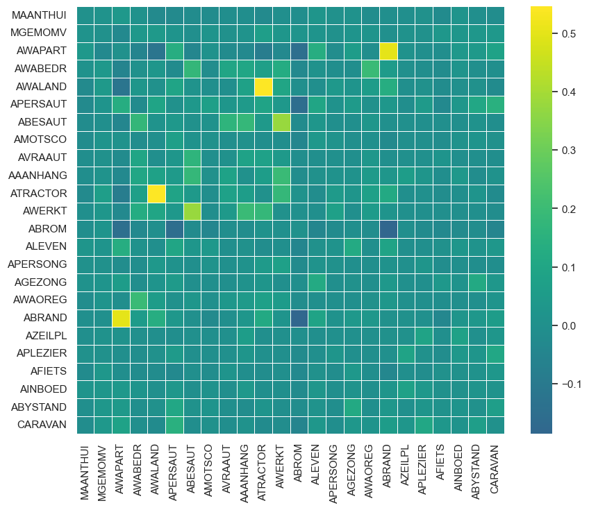

```
0
```

```python
get_corr_matrix(dataset = numeric_variables,
                metodo='pearson', size_figure=[10,8])
```

En este caso podemos ver que el grado de correlación de tal manera que es poco relevante el grado de asociación entre variables numéricas.

### 2.1. Representación gráfica de las variables

Una vez analizado el grado de asociación entre variables numéricas y categóricas, el siguiente paso será analizar las variables frente a la variable objetivo.

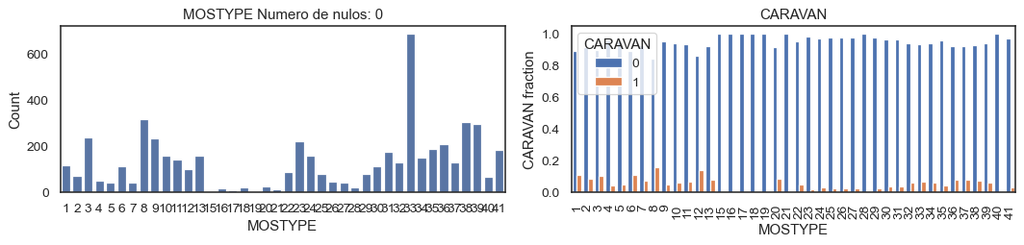

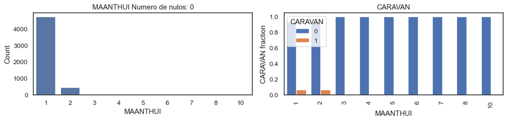

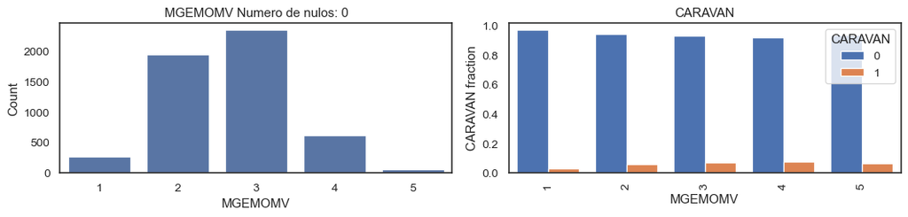

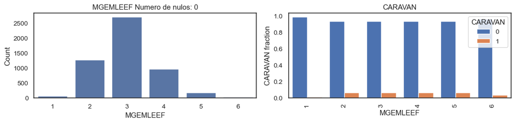

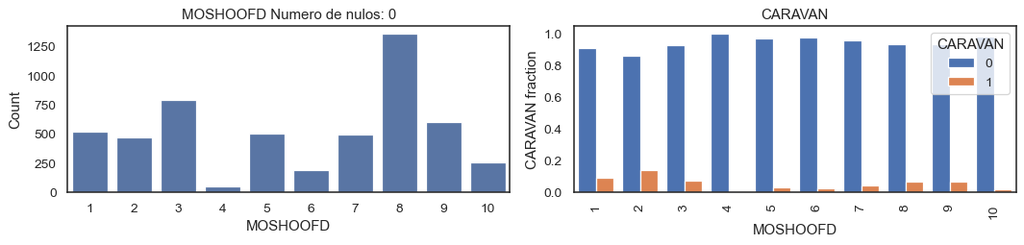

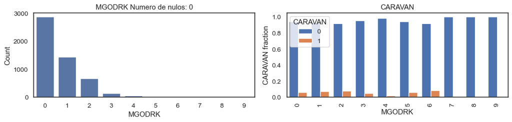

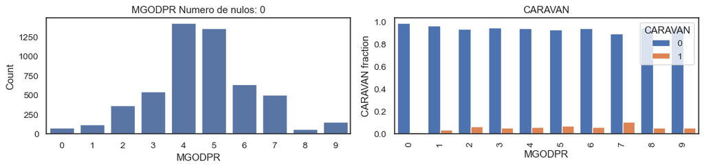

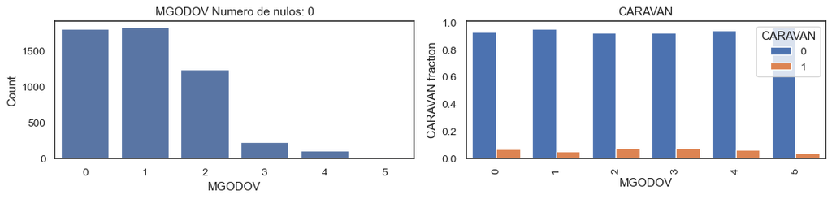

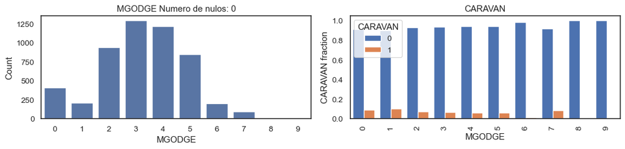

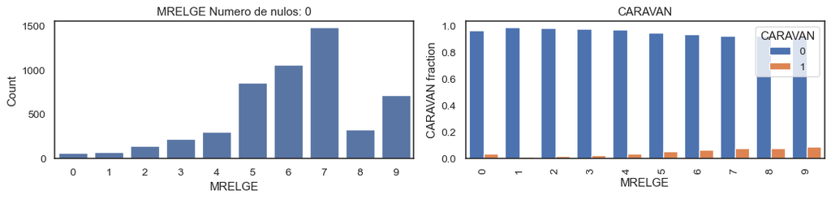

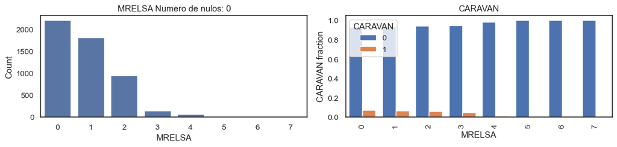

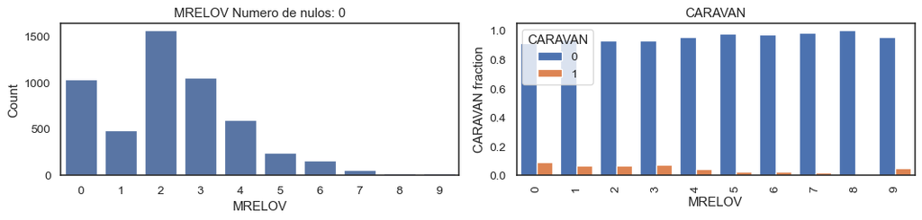

[73 more figures not shown]

```python
for i in list(train_data.loc[:,~train_data.columns.isin(['CARAVAN'])]):
        plot_feature_numeric_variables(train_data, col_name=i, target='CARAVAN')
```

De las siguientes gráficas podemos deducir que hay una gran cantidad de variables desbalanceadas como es el caso de ABRAND que presenta una mayor concentración de los datos en torno a dos categorías y pocos datos en las demas categorias o ninguno. Esto ocurre con más variables. También nos podemos encontrar casos como los de las últimas variables en las que todos los datos se concentran en 1 categoría teniendo(APLEZIER o AZEILPl) el resto de las categorías sin datos. Una forma de solventar las variables desbalanceadas sería crear una categoría que agrupase las categorías con menos datos agrupandolas en una sola. Para las variables que tienen todos los datos en una categoría tendríamos que eliminarlas ya que no son relevantes.

## Tratamiento de outliers

Los valores outlier se pueden sustituir por la media, mediana, valores extremos. Tras el siguiente análisis, he decidido dejarlos sin sustituir. Una vez llegue al modelo puedo realizar iteraciones utilizando diferentes métodos para comprobar si mejora el modelo y cual sería el mejor método para el modelo.

```python
print(numeric_variables.columns)
```

[output not shown]

```python
outliers_values = get_deviation_of_mean_perc(train_data, numeric_variables.columns, target='CARAVAN', multiplier=3)
```

```python
outliers_values
```

[output not shown]

```python
outliers_count_per_variable = outliers_values[['variable', 'sum_outlier_values']]
```

```python
outliers_count_per_variable
```

[output not shown]